# SST and Chl-a Regional Summaries

January 08, 2021

##### Below are monthly time series of mean sea surface temperature (SST, $^\circ$C) and chlorophyll-a concentration (Chla, mg m<sup>-3</sup>). Click on the tabs to view plots for each region of interest.

**Click here to view study area map**

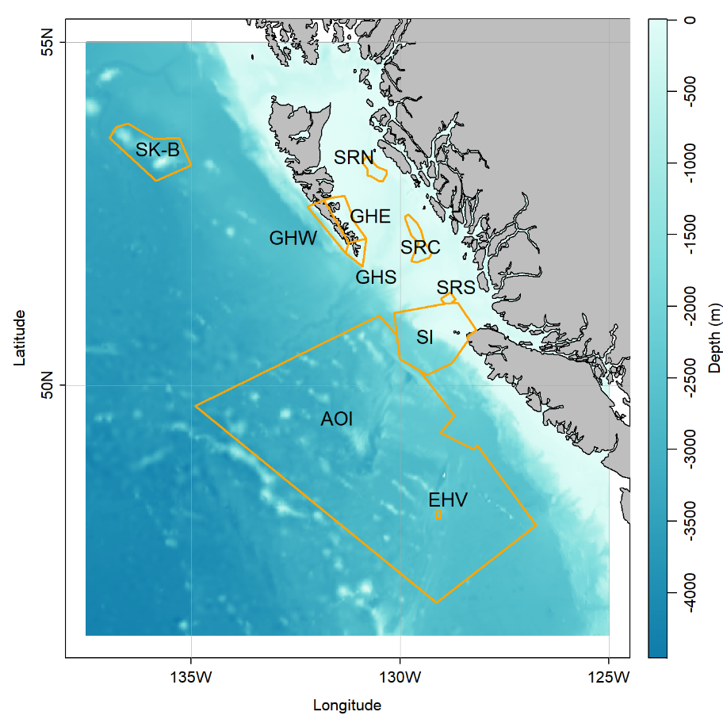

**Regions:**

- **AOI:** [Offshore Pacific Area of Interest](https://www.dfo-mpo.gc.ca/oceans/aoi-si/offshore-hauturiere-eng.html)
- **EHV:** [Endeavour Hydrothermal Vents Marine Protected Area](https://www.dfo-mpo.gc.ca/oceans/mpa-zpm/endeavour/index-eng.html)
- **GH:** *East (GHE), South (GHS), West (GHW)* [Gwaii Haanas National Marine Conservation Area Reserve](https://www.pc.gc.ca/en/pn-np/bc/gwaiihaanas)
- **SI:** [Scott Islands marine National Wildlife Area](https://www.canada.ca/en/environment-climate-change/services/national-wildlife-areas/locations/scott-islands-marine.html)
- **SK-B:** [SGaan Kinghlas-Bowie Seamount Marine Protected Area](https://www.dfo-mpo.gc.ca/oceans/mpa-zpm/bowie-eng.html)
- **SR:** *Central (SRC), North (SRN), South (SRS)* [Hecate Strait/Queen Charlotte Sound Glass Sponge Reefs Marine Protected Area](https://www.dfo-mpo.gc.ca/oceans/mpa-zpm/hecate-charlotte/index-eng.html)

## Time Series Statistics

### Sea Surface Temperature

| Region | Season | Slope | Std error | T value | P value |
| --- | --- | --- | --- | --- | --- |
| SK B | Winter | 6.8e-05 | 1.7e-05 | 3.99395 | 0.000115 |
| SK B | Spring | 3.4e-05 | 3.9e-05 | 0.88303 | 0.379062 |
| SK B | Summer | 8.0e-05 | 2.6e-05 | 3.03480 | 0.002972 |
| SK B | Fall | 5.8e-05 | 4.2e-05 | 1.37058 | 0.173174 |
| EHV | Winter | 4.5e-05 | 1.9e-05 | 2.34558 | 0.020952 |
| EHV | Spring | 7.8e-05 | 4.0e-05 | 1.94762 | 0.054009 |
| EHV | Summer | 8.2e-05 | 2.4e-05 | 3.40480 | 0.000912 |
| EHV | Fall | 8.2e-05 | 4.9e-05 | 1.68503 | 0.094898 |
| SI | Winter | 5.3e-05 | 1.8e-05 | 3.00525 | 0.003258 |
| SI | Spring | 4.3e-05 | 3.6e-05 | 1.18929 | 0.236775 |

[output cut: 30 more lines]

### Chlorophyll-a Concentration

| Region | Season | Slope | Std error | T value | P value |
| --- | --- | --- | --- | --- | --- |
| SK B | Winter | 0.000014 | 6.0e-06 | 2.39085 | 0.022491 |
| SK B | Spring | -0.000017 | 9.0e-06 | -1.90629 | 0.062146 |
| SK B | Summer | 0.000014 | 1.3e-05 | 1.06337 | 0.292526 |
| SK B | Fall | 0.000039 | 2.5e-05 | 1.56616 | 0.128957 |
| EHV | Winter | -0.000004 | 7.0e-06 | -0.53796 | 0.593256 |
| EHV | Spring | -0.000015 | 8.0e-06 | -1.93642 | 0.058842 |
| EHV | Summer | -0.000005 | 1.0e-05 | -0.56664 | 0.573446 |
| EHV | Fall | 0.000001 | 1.5e-05 | 0.06879 | 0.945598 |
| SI | Winter | 0.000023 | 2.0e-05 | 1.14403 | 0.257952 |
| SI | Spring | -0.000041 | 4.0e-05 | -1.02741 | 0.308983 |

[output cut: 30 more lines]

## Time Series Plots

### AOI

Offshore Area of Interest

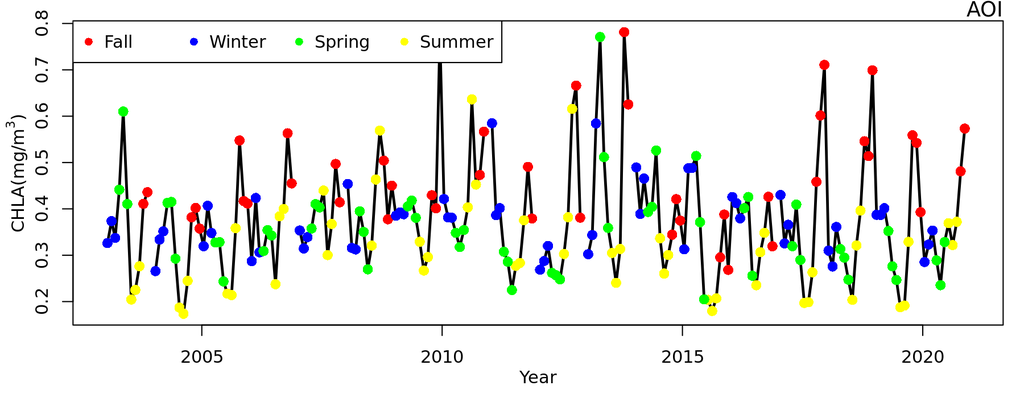

### EHV

#### Endeavour Hydrothermal Vents Marine Protected Area

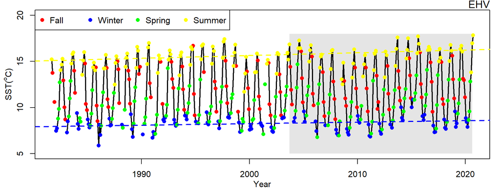

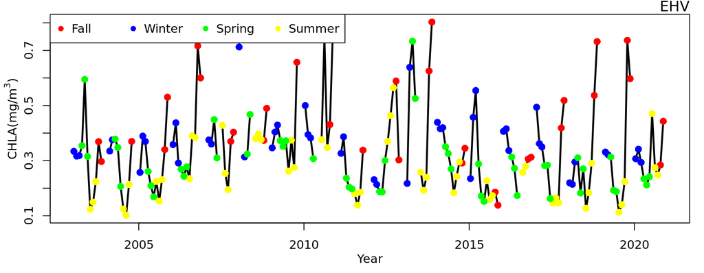

### GH

##### East

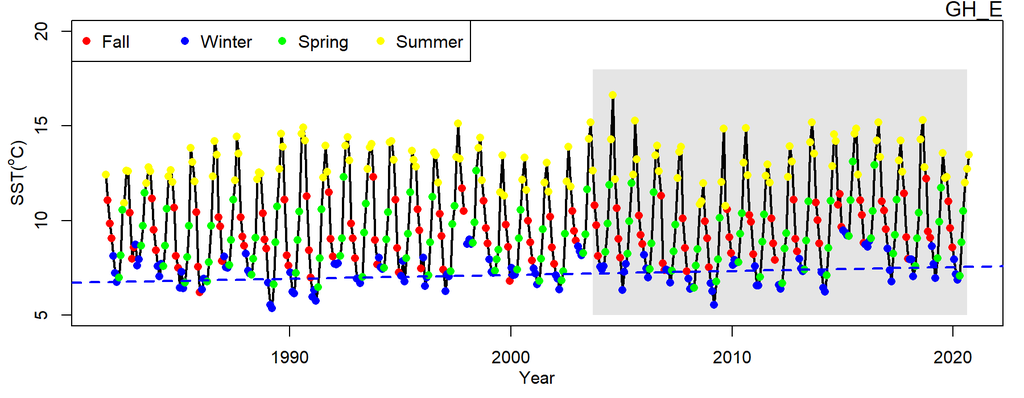

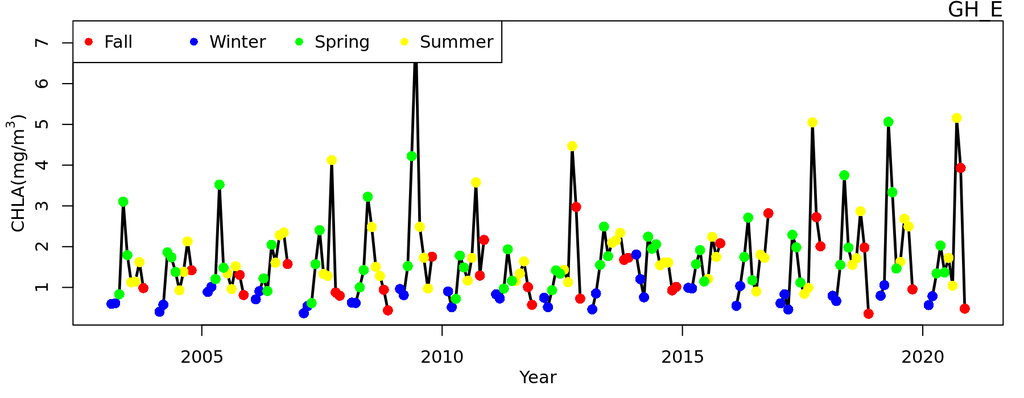

##### South

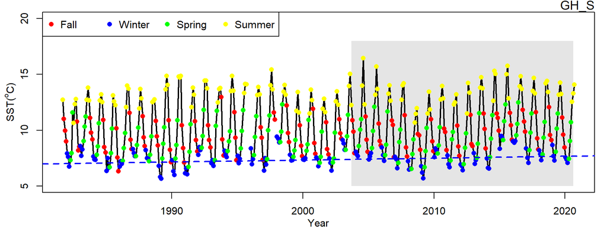

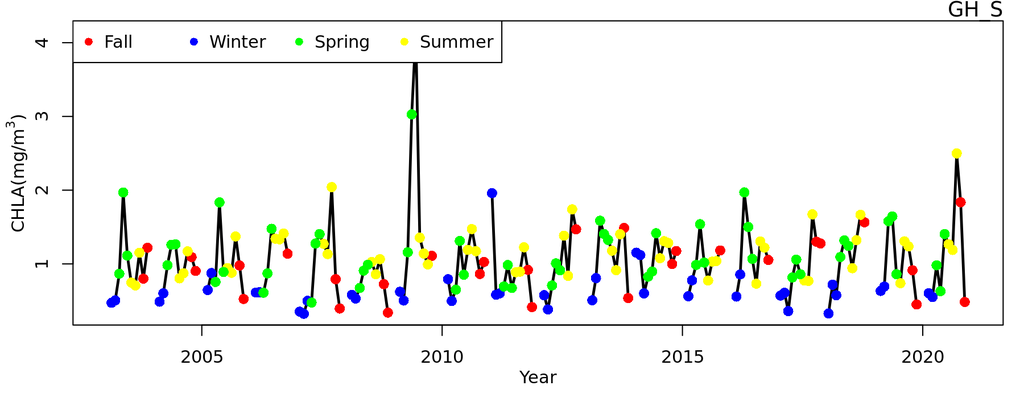

##### West

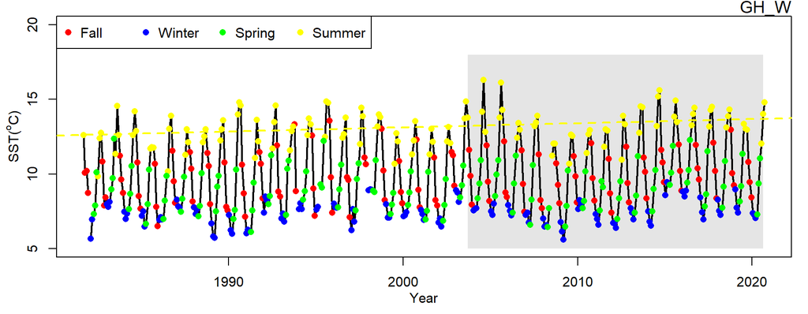

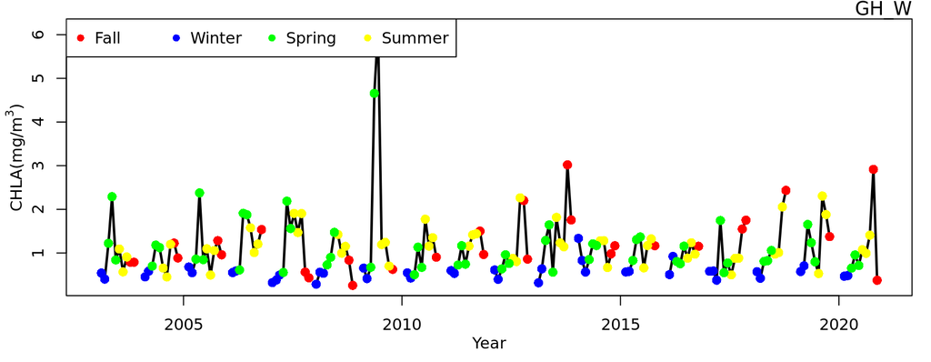

### SI

##### Scott Islands marine National Wildlife Area

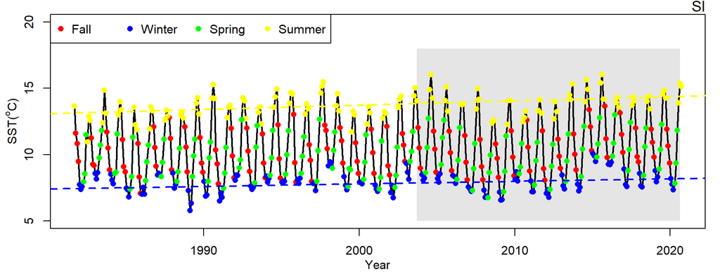

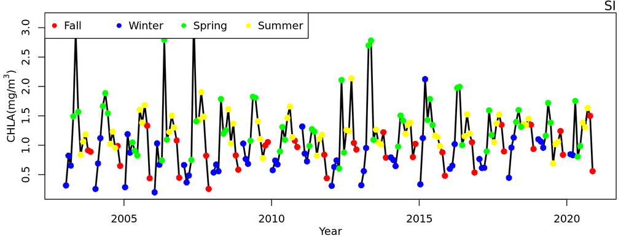

### SK-B

#### SGaan Kinghlas-Bowie Seamount Marine Protected Area

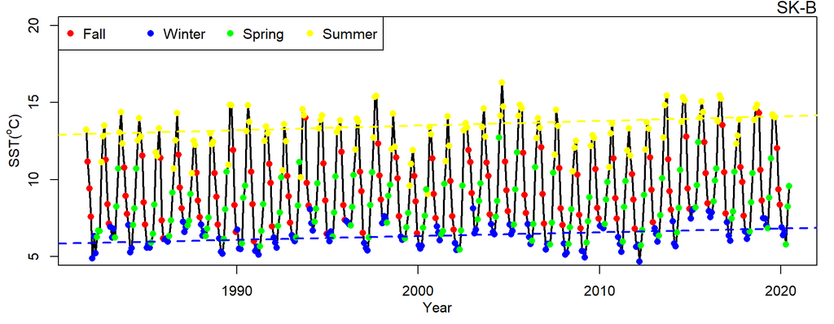

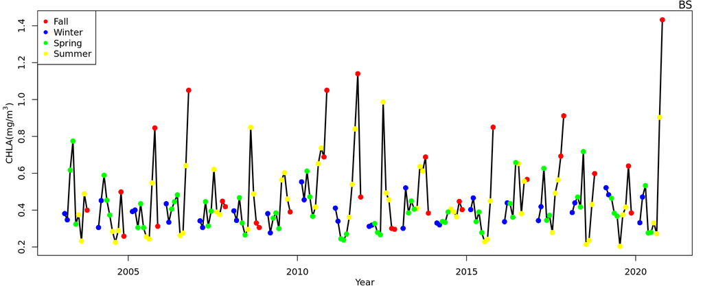

### SR

#### Hecate Strait/Queen Charlotte Sound Glass Sponge Reefs Marine Protected Area

##### Central

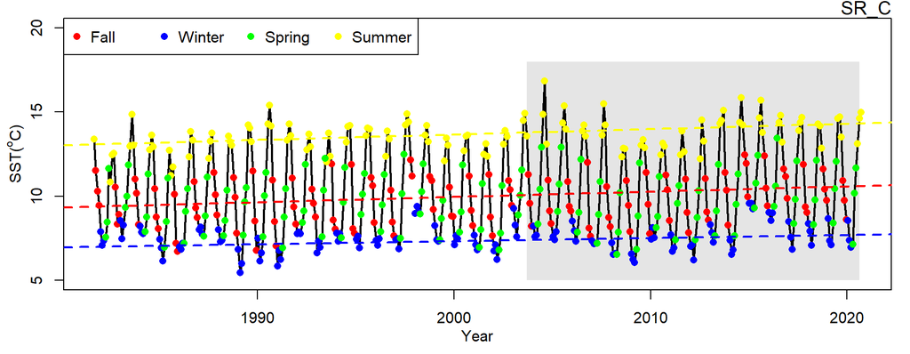

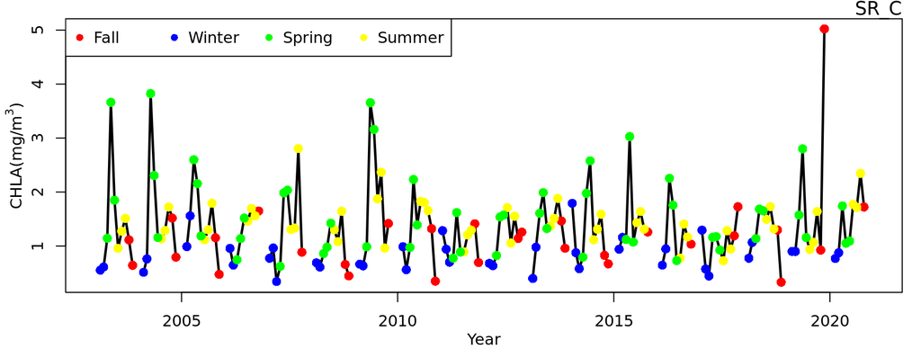

##### North

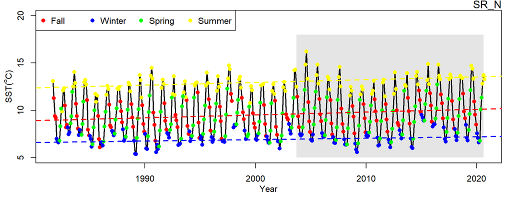

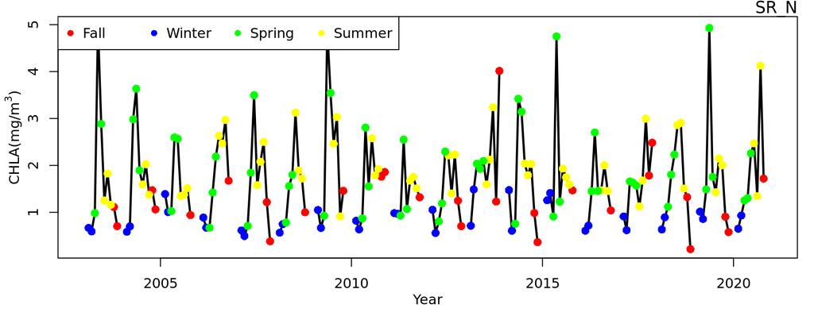

##### South

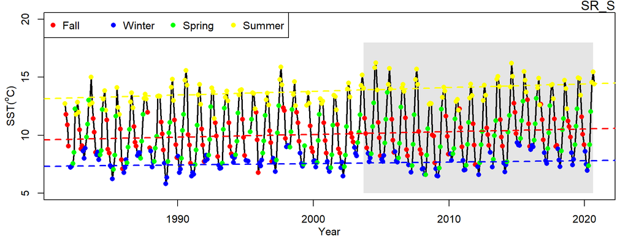

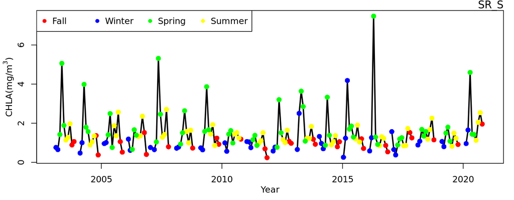

Analysis by Melanie Hardy, Emmanuel Devred and Charles Hannah

Assembled by Andrea Hilborn

*Contact: Andrea.Hilborn@dfo-mpo.gc.ca*